# Seasonal Models

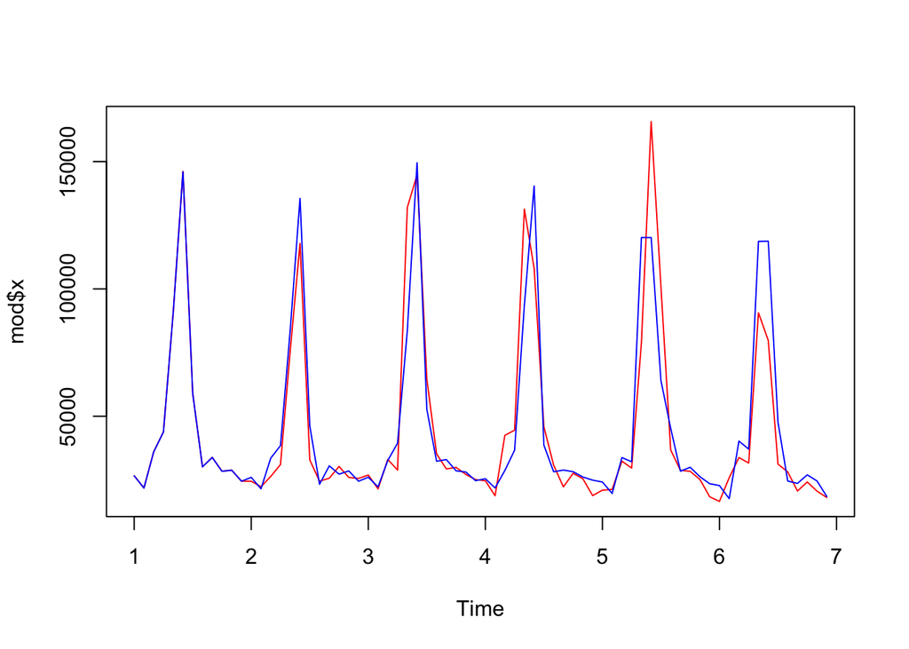

```r
plot(mod$x, col='red')
lines(fitted(mod), col='blue')
```

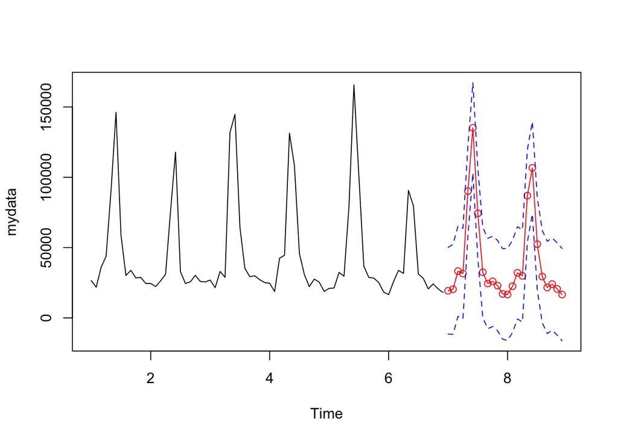

```
## $pred
##         Jan       Feb       Mar       Apr       May       Jun       Jul
## 7  19280.41  20375.61  33258.81  31599.55  90175.30 135176.30  74346.53
## 8  16643.94  22493.80  32055.86  29896.44  86925.76 106695.30  52426.14
##         Aug       Sep       Oct       Nov       Dec
## 7  32455.48  24461.92  26000.24  22917.53  17066.97
## 8  29367.63  21679.08  24035.64  20627.54  16596.45
##
## $se
##        Jan      Feb      Mar      Apr      May      Jun      Jul      Aug
## 7 15418.48 16002.65 16046.86 16050.27 16050.54 16050.56 16050.56 16050.56
## 8 16374.13 16398.84 16400.75 16400.90 16400.91 16400.91 16400.91 16400.91
##        Sep      Oct      Nov      Dec
## 7 16050.56 16050.56 16050.56 16050.56
## 8 16400.91 16400.91 16400.91 16400.91
```

```r
# Now, we have a reasonable prediction, we can forecast the model, say 24 months into the future.
sarima.for(mydata, 24, 1,0,0,2,1,0,12)
```

```r
predict(mod, n.ahead=24)
```

```
## $pred
##         Jan       Feb       Mar       Apr       May       Jun       Jul
## 7  20255.41  21600.16  34566.44  32926.83  91479.84 136741.26  75871.08
## 8  18181.32  24104.77  33671.14  31514.60  88541.37 108213.01  53968.18
##         Aug       Sep       Oct       Nov       Dec
## 7  33820.25  25825.51  27353.24  24271.39  18409.99
## 8  30981.40  23293.94  25653.80  22244.57  18220.17
##
## $se
##        Jan      Feb      Mar      Apr      May      Jun      Jul      Aug
## 7 15834.85 16446.23 16493.39 16497.10 16497.39 16497.41 16497.41 16497.41
## 8 16821.60 16846.86 16848.84 16849.00 16849.01 16849.01 16849.01 16849.01
##        Sep      Oct      Nov      Dec
## 7 16497.41 16497.41 16497.41 16497.41
## 8 16849.01 16849.01 16849.01 16849.01
```

# Resources

- [Seasonal ARIMA models | STAT 510](https://onlinecourses.science.psu.edu/stat510/node/67)
- [Identifying Seasonal Models and R Code | STAT 510](https://onlinecourses.science.psu.edu/stat510/node/68)
- [Seasonal ARIMA models | OTexts](https://www.otexts.org/fpp/8/9)
- [General seasonal ARIMA models](http://people.duke.edu/~rnau/seasarim.htm)
- [Modeling Seasonal Time Series - Hu-berlin.de](http://fedc.wiwi.hu-berlin.de/xplore/tutorials/xegbohtmlnode44.html)

# References

The data, R code and lessons are based upon:

1. Time Series Analysis :

Data Source: http://www.geophysics.geol.uoa.gr/catalog/catgr_20002008.epi

Code References :

Book : Mastering Predictive Analytic with R  
Author: Rui Miguel Forte  
https://www.safaribooksonline.com/library/view/mastering-predictive-analytics/9781783982806/

Chapter 9: Time series Analysis

http://www.statoek.wiso.uni-goettingen.de/veranstaltungen/zeitreihen/sommer03/ts_r_intro.pdf

http://www.stat.pitt.edu/stoffer/tsa3/R_toot.htm

http://www.statoek.wiso.uni-goettingen.de/veranstaltungen/zeitreihen/sommer03/ts_r_intro.pdf

2. Trend Analysis

Code References :

Book : Mastering Predictive Analytic with R  
Author: Rui Miguel Forte  
https://www.safaribooksonline.com/library/view/mastering-predictive-analytics/9781783982806/

http://www.r-bloggers.com/seasonal-trend-decomposition-in-r/

3. Seasonal Models

Code references :

Book: Time Series Analysis and Its Applications  
Author: Robert H. Shumway . David S. Stoffer  
Link: http://www.springer.com/us/book/9781441978646#otherversion=9781461427599

http://a-little-book-of-r-for-time-series.readthedocs.org/en/latest/src/timeseries.html

https://onlinecourses.science.psu.edu/stat510/?q=node/47

https://rpubs.com/ryankelly/tsa5

https://onlinecourses.science.psu.edu/stat510/node/68

Data Reference : https://github.com/RMDK/TimeSeriesAnalysis/blob/master/colorado_river.csv

4. Spectral Analysis

Code References:  
Book:  
Modern Applied Statistics with S Fourth edition  
Author: W. N. Venables and B. D. Ripley  
Link: Modern Applied Statistics with S Fourth edition

http://www.maths.adelaide.edu.au/patty.solomon/TS2004/tsprac3_2004.pdf